# Prediction of exercise quality using models trained with accelerometers data

Joe

31 Janurary 2016

## Executive Summary

This report proposes a model to predict the quality of exercise based on data gathered by wearable accelerometers. Different models are trained using data from accelerometers on the belt, forearm, arm, and dumbell of 6 participants. They were asked to perform barbell lifts correctly and incorrectly in 5 different ways. More information is available at [here](http://groupware.les.inf.puc-rio.br/har) (see the section on the Weight Lifting Exercise Dataset). The best model is chosen based on the prediction accuracy obtained on the cross validation dataset.

The training dataset has been preprocessed and cleaned of irrevelant/duplicate predictors. Highly correlated predictors have been eliminated. Predictors (excluding output variable) have been reduced from 159 variables to 34 variables after preprocessing.

As the prediction is a multi classification problem, the models chosen were random forest and boosting which perform well on multi classification. The data was split into training and test set. Models were trained on training data with K fold cross validation and finally the best model was chosen on the prediction on the cross validation set.

The model that performed the best was Random forest and it had an accuracy of 0.999 and Kappa of 0.999 on independent testing dataset.

Git repository for the above analysis is at https://github.com/jmuthu/Machine_learning_prediction_assignment

## Exploratory Analysis

Lets analyze the training and test datasets provided, summarize the total count and also see if all columns are same in both data sets.

```
##           Details   Training Testing
## 1       Row count      19622      20
## 2 Missing columns problem_id  classe
```

The sample size of training is around 19622 which is a good medium size dataset. In the test set, the output column “classe” is missing and it has an additional index column “problem_id” which is missing in the training set. We can ignore both the “problem_id” column as it is just an index and the “classe” column which needs to be predicted for the test set. Except for these two columns all the other columns are same in test and training set.

Lets look at some the columns in the training set. There are totally 160 variables in the training dataset

```
##  [1] "X"                    "user_name"            "raw_timestamp_part_1"
##  [4] "raw_timestamp_part_2" "cvtd_timestamp"       "new_window"
##  [7] "num_window"           "roll_belt"            "pitch_belt"
## [10] "yaw_belt"             "total_accel_belt"     "kurtosis_roll_belt"
## [13] "kurtosis_picth_belt"  "kurtosis_yaw_belt"    "skewness_roll_belt"
## [16] "skewness_roll_belt.1" "skewness_yaw_belt"    "max_roll_belt"
## [19] "max_picth_belt"       "max_yaw_belt"
```

There are few time measurements, user name, index and rest are all measurements from the four devices namely roll belt, arm, dumbell and forearm.

## Pre-processing

Lets do some preprocessing and reduce the number of variables which are irrevelant or duplicate or empty.

**Duplicate/Irrevelant predictors :** The index column “X” is not relevant. The column “raw_timestamp_part_1” looks like a timestamp value for the date column “cvtd_timestamp”. Lets convert the timestamp value to date and compare them. Lets check if any of these mismatch.

```r
sum(format(as.POSIXct(data$raw_timestamp_part_1, origin="1970-01-01", tz="UTC"),"%d/%m/%Y %H:%M") != data$cvtd_timestamp)
```

```
## [1] 0
```

The mismatch count is zero so both time fields are same. Lets remove the X and cvtd_timestamp columns.

**Near Zero variablity predictor :** Lets find those predictors using nearZeroVar funciton and remove it. About 60 predictors have no variablity at all.

**Missing values :** Lets remove predictors or/and rows that have missing values. There are about 40.97% missing values in the training dataset. Lets see the distribution of missing value count for each predictor

```
##   data_na_count Freq
## 1             0   57
## 2         19216   41
```

There are 41 predictors that have a huge count of missing values (19216). Lets remove these predictors from the dataset.

**Highly Correlated Predictors :** Lets remove the highly correlated predictors from the data set which have correlation index of greater than 0.75. First we need to convert the character predictors “user_name” and “classe” to numeric to compute correlation.

Summary of the correlation distribution in the training set is show below.

```
##       Min.    1st Qu.     Median       Mean    3rd Qu.       Max.
## -0.9920000 -0.1042000  0.0015250  0.0001378  0.0861400  0.9809000
```

There were 22 highly correlated predictors and these can be removed as well.

Now we have brought down the predictors from 160 in the original dataset to 35. The data set looks clean with no missing values and all irrevelant/duplicate predictors have been removed. Following are the selected predictors which has more forearm measurements compared to other meters.

```
##  [1] "user_name"            "raw_timestamp_part_1" "raw_timestamp_part_2"
##  [4] "num_window"           "yaw_belt"             "gyros_belt_x"
##  [7] "gyros_belt_y"         "gyros_belt_z"         "magnet_belt_x"
## [10] "magnet_belt_y"        "roll_arm"             "pitch_arm"
## [13] "yaw_arm"              "total_accel_arm"      "gyros_arm_y"
## [16] "gyros_arm_z"          "magnet_arm_x"         "magnet_arm_z"
## [19] "roll_dumbbell"        "pitch_dumbbell"       "yaw_dumbbell"
## [22] "total_accel_dumbbell" "gyros_dumbbell_y"     "roll_forearm"
## [25] "pitch_forearm"        "yaw_forearm"          "total_accel_forearm"
## [28] "gyros_forearm_x"      "gyros_forearm_z"      "accel_forearm_x"
## [31] "accel_forearm_z"      "magnet_forearm_x"     "magnet_forearm_y"
## [34] "magnet_forearm_z"
```

## Model Selection

The output variable classe has five different exercise categories of which A is correct execution and the rest (B,C,D,E) are all incorrect executions. As this is a multi classification problem, we will choose the following models as they work well for classification problems.

- Support Vector Machine with Radial Basis Function
- Stochastic Gradient Boosting
- Random Forest

The best performing model will be chosen based on 10 fold cross validation on the training data. We will split 25% of the training set into a separate testing data and this testing data will be used with the best model once to calculate final accuracy. As these models take time, we will leverage the parallel processing functionality from caret package. Lets also normalize the training data as it performs well with these models. So lets train all these models with the same 10 fold cross validation and normalization.

Lets check the in sample error for these models and for that we will use the accuracy (1- sample error) and kappa metrics. Comparison is shown below for these 3 models based on the performance on the cross validation set.

```
##
## Call:
## summary.resamples(object = results)
##
## Models: RandomForest, GradientBoosting, SupportVector
## Number of resamples: 10
##
## Accuracy
##                    Min. 1st Qu. Median   Mean 3rd Qu.   Max. NA's
## RandomForest     0.9952  0.9980 0.9997 0.9987  1.0000 1.0000    0
## GradientBoosting 0.9946  0.9973 0.9976 0.9978  0.9990 1.0000    0
## SupportVector    0.8995  0.9091 0.9107 0.9124  0.9169 0.9246    0
##
## Kappa
##                    Min. 1st Qu. Median   Mean 3rd Qu.   Max. NA's
## RandomForest     0.9940  0.9974 0.9996 0.9984  1.0000 1.0000    0
## GradientBoosting 0.9931  0.9966 0.9970 0.9972  0.9987 1.0000    0
## SupportVector    0.8729  0.8850 0.8870 0.8892  0.8949 0.9047    0
```

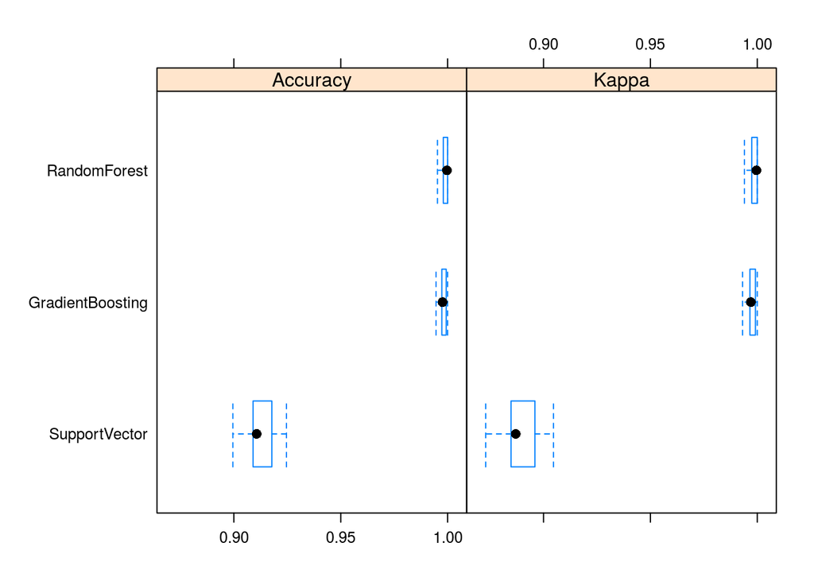

If you compare the means of accuracy and kappa above, Random forest performed the best among the models though gradient boosting is pretty close. Lets choose Random forest as our final Model as it has the highest mean accuracy and kappa. Random forest has about 500 trees.

Since the testing dataset is extracted from the same training data and also from the same users, we can expect the same accuracy as the in-sample accuracy. We can estimate the accuracy on the testing dataset to be around the mean of the in-sample accuracy which is 0.9987. So lets predict on the testing dataset and the accuracy and kappa metrics are shown below

```
## Confusion Matrix and Statistics
##
##           Reference
## Prediction    1    2    3    4    5
##          1 1395    0    0    0    0
##          2    0  949    2    0    0
##          3    0    0  852    0    0
##          4    0    0    1  804    0
##          5    0    0    0    0  901
##
## Overall Statistics
##
##                Accuracy : 0.9994
##                  95% CI : (0.9982, 0.9999)
##     No Information Rate : 0.2845
##     P-Value [Acc > NIR] : < 2.2e-16
##
##                   Kappa : 0.9992
##  Mcnemar's Test P-Value : NA
##
## Statistics by Class:
##
##                      Class: 1 Class: 2 Class: 3 Class: 4 Class: 5
## Sensitivity            1.0000   1.0000   0.9965   1.0000   1.0000
## Specificity            1.0000   0.9995   1.0000   0.9998   1.0000
## Pos Pred Value         1.0000   0.9979   1.0000   0.9988   1.0000
## Neg Pred Value         1.0000   1.0000   0.9993   1.0000   1.0000
## Prevalence             0.2845   0.1935   0.1743   0.1639   0.1837
## Detection Rate         0.2845   0.1935   0.1737   0.1639   0.1837
## Detection Prevalence   0.2845   0.1939   0.1737   0.1642   0.1837
## Balanced Accuracy      1.0000   0.9997   0.9982   0.9999   1.0000
```

Finally lets predict the classe levels for the 20 test cases provided in the assignment using random Forest model.

```
##  [1] "B" "A" "B" "A" "A" "E" "D" "B" "A" "A" "B" "C" "B" "A" "E" "E" "A"
## [18] "B" "B" "B"
```

## Conclusion

So in conclusion, the 34 predictors with random forest model has given has a high prediction accuracy in exercise quality. With more fine tuning of model parameters and further reduction in predictors, we could speed up the training process.